# Coursera - Mooc Machine Learning - Project

## Step #1: Upload libraries

```r
library(dplyr)
library(caret)
```

```r
library(rpart)
library(rpart.plot)
library(rattle)
library(gbm)
library(randomForest)
library(plyr)
library(MASS)
```

## Step #2: Upload the datasets (training and testing)

```r
training <- read.csv("pml-training.csv")
dim(training)
```

```
## [1] 19622   160
```

```r
testing<- read.csv("pml-testing.csv")
dim(testing)
```

```
## [1]  20 160
```

## Step #3: Data management

### 1. Seed creation - to make it reproducible

```r
set.seed (14)
```

### 2. Remove empty features in the training dataset : features with 95% of more of null, empty, N/A,. modalities

```r
df_train <- data.frame(matrix(ncol = 0, nrow = nrow(training)))
var_delete <- c()
for ( i in 1:ncol(training)){
  var_temp <- training[i]
  to_delete <- is.null(var_temp) | is.na(var_temp) | var_temp=="" | var_temp=="#DIV/0!"
  d <- data.frame(var = var_temp, to_delete=to_delete)
  n <- nrow( d %>% filter(to_delete != TRUE) )
  percent_non_null <- n/nrow(var_temp)
  if(n>1 & percent_non_null>=0.05) {
    df_train  <- cbind(df_train, var_temp)
  } else {
    var_delete <- c(var_delete,names(var_temp))
  }
}
# class(df_train)
# var_delete
dim(df_train)
```

```
## [1] 19622    60
```

### 3. Remove non-logical features in the training dataset

```r
df_train <- df_train[-1] # remove X
df_train <- df_train[-2] # remove user_name
dim(df_train)
```

```
## [1] 19622    58
```

### 4. Remove the same variables in the testing dataset

```r
testing <- testing[colnames(df_train[,-58])]
dim(testing)
```

```
## [1] 20 57
```

### 5. Split the training dataset in a train part (60%) and a test part (40%) for cross-validaton

The model will be fitted on the subTraining dataset, and tested on the subTesting dataset. Once the most accurate model is choosen, it will be tested on the original testing dataset.

```r
inTrain = createDataPartition(y=df_train$classe, p = 0.6, list=FALSE)
df_training = df_train[inTrain,]
df_testing = df_train[-inTrain,]
# View(df_training)
# View(df_testing)
dim(df_training)
```

```
## [1] 11776    58
```

```r
dim(df_testing)
```

```
## [1] 7846   58
```

### 6. Coerce the data into the same type

```r
for (i in 1:length(testing) ) {
  for(j in 1:length(df_training)) {
    if( length( grep(names(df_training[i]), names(testing)[j]) ) ==1)  {
      class(testing[j]) <- class(df_training[i])
    }
  }
}
testing <- rbind(df_training[2, -58] , testing)
testing <- testing[-1,]
```

## Step #4: Modelings

For each method, the modeling was done on the train part of the training dataset (60%), and the prediction was done on the test part of this dataset (40%). It’s the cross-validation. Then the accuracy was calculated to compared the different methods, and the method with the best accuracy will be choosen.

### Method 1: Decision Tree

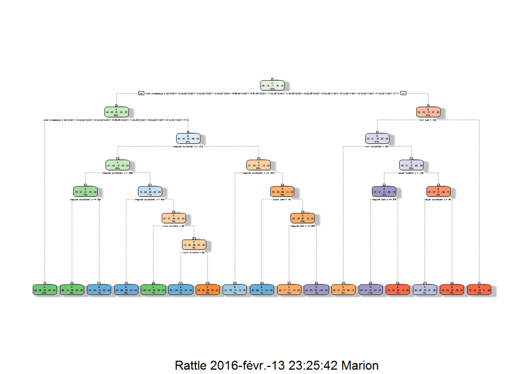

```r
# modeling
fitdt <-rpart(classe~.,data=df_training, method="class")
fancyRpartPlot(fitdt)
```

```r
# prediction
preddt <- predict(fitdt,df_testing, type="class")
#confusionMatrix(preddt, df_testing$classe)
accuracy_dt <- nrow( df_testing[preddt == df_testing$classe,]) / nrow(df_testing)
accuracy_dt
```

```
## [1] 0.8510069
```

### Method 2: Boosted tree

```r
# modeling
fitgbm <-train(classe~.,data=df_training, method="gbm", verbose=FALSE)
#fitgbm$finalModel

# prediction
predgbm <- predict(fitgbm,df_testing)
#confusionMatrix(predgbm, df_testing$classe)
accuracy_gbm <- nrow( df_testing[predgbm == df_testing$classe,]) / nrow(df_testing)
accuracy_gbm
```

```
## [1] 0.9934999
```

### Method 3: Discriminant Analysis

```r
# modeling
fitlda <-train(classe~.,data=df_training,method="lda", type="class")
```

[output not shown]

```r
#fitlda$finalModel

# prediction
predlda <- predict(fitlda,df_testing)
# confusionMatrix(predlda, df_testing$classe)
accuracy_lda <- nrow( df_testing[predlda == df_testing$classe,]) / nrow(df_testing)
accuracy_lda
```

```
## [1] 0.8549579
```

### Method 4: Random Forest

```r
# modeling
fitrf <-train(classe~.,data=df_training, method="rf", type="class")
#fitrf$finalModel

# prediction
predrf <- predict(fitrf,df_testing)
#confusionMatrix(predrf, df_testing$classe)
accuracy_rf <- nrow( df_testing[predrf == df_testing$classe,]) / nrow(df_testing)
accuracy_rf
```

```
## [1] 0.9982157
```

## Step #5: Prediction on testing dataset

```r
pred_testing_final <- predict(fitrf,testing)

# Add prediction in the testing dataset
testing$predict <- pred_testing_final
View(testing)
```